# Resources

Data, teaching materials, reading and projects at the intersection of mathematics and creativity.

Data · Teaching · Creation

# Resources

Teach, learn  
and explore differently.

Data, teaching materials, reading and projects at the intersection of mathematics and creativity.

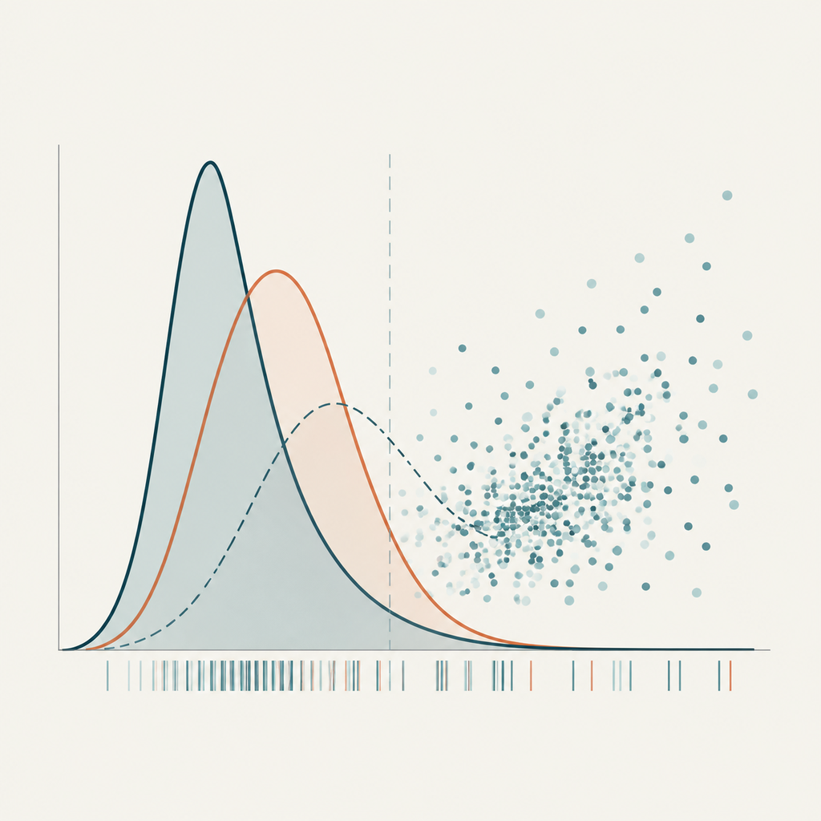

## Datasets, materials and workshops

### Datasets and materials

Access data and teaching resources in statistics and data science.

[Données bleues](https://aureliennicosiaulaval.github.io/donnees-bleues/)

[Ressources SSD](https://aureliennicosiaulaval.github.io/site_ressources_SSD/)

### Presentations and workshops

Find a presentation or explore outreach and training activities.

Au-delà du prompt (French)

Workshops

Along the bookshelves

## Library

602 distinct editions, from classics in mathematics to statistics, data science and scientific curiosities.

Explore the collection

[figure not shown]

[figure not shown]

### Updates and posts

Updates

Posts (French)

## Explorations

This page gathers more exploratory projects that complement my research and teaching activities. They focus on connections between mathematics, writing, visualization, and digital creation.

Mathematics and art

### Digital drawing with R

Exploration of textures, patterns, and generative images produced with R, `ggplot2`, and probabilistic processes. The project uses visualization as a meeting point between statistical rigor and creative work.

Outreach writing

### Mathematical recipes

Writing project where mathematical concepts are presented as short, visual, and structured recipes. The objective is to make the formal beauty of mathematics more accessible without sacrificing precision.

Data science

### Data Kitchen

Learning-platform project inspired by culinary language, designed to explain the stages of a data project through concrete analogies and reproducible examples.

Digital creativity

### Visualization and communication

Exploratory work on how visual forms, metaphors, and interfaces can support understanding of statistical or mathematical concepts.

Guiding thread: connect scientific rigor, visual clarity, and human creativity to make mathematics and data science more accessible.